# **MSBA 615 - R: Final Project**

Bradley Lowen

2024-12-10

## **Importing and Cleaning Up NYC Airbnb Data**

**To begin, I will import the NYC Airbnb data from an Excel file.**

```r
airbnb <- read_excel("C:/Users/bwlowe01/Desktop/MSBA/MSBA 615 - R for Analytics/AB_NYC_2019.xlsx")
```

**Then, looking at the data, I can omit some entire columns that do not provide data that would help with analysis. The columns “id”, “host_id”, “name”, “host_name”,“latitude”,“longitude”, “last_review”, and “reviews_per_month” all do not meaningfully contribute to the analysis of this data. The “id” and “host_id” columns are accounted for much more efficiently in the “calculated_host_listings_count” column. The latitude and longitude location data is redundant due to both the “neighbourhood_group” and “neighbourhood” columns, and the “reviews_per_month” and “last_review”columns provide data that is not pertinent enough in light of the other categories.These would only be useful if you are attempting to analyze review trends, or focus specifically on reviews. The only caveat to removing “id” is that we should explore the data for duplicates before removing this category. Some listings could be identical in other ways just by chance.**

```r
sum(duplicated(airbnb))
```

```
## [1] 0
```

```r
#no duplicates found, we can remove "id" and clean the data

airbnbclean <- airbnb |> select(-"id", -"host_id", -"name", -"host_name", -"latitude", -"longitude", -"last_review", -"reviews_per_month")
```

**Now, I can check the remaining data for NA values and outliers. We will check for outliers using the IQR technique, and visualize with a box plot.**

```r
navalues <- colSums(is.na(airbnbclean))
navalues
```

```
##            neighbourhood_group                  neighbourhood
##                              0                              0
##                      room_type                          price
##                              0                              0
##                 minimum_nights              number_of_reviews
##                              0                              0
## calculated_host_listings_count               availability_365
##                              0                              0
```

**There are no NA values.**

```r
findoutliers <- function(x) {
  Q1 <- quantile(x, 0.25, na.rm = TRUE)
  Q3 <- quantile(x, 0.75, na.rm = TRUE)
  IQR <- Q3 - Q1
  lowerq <- Q1 - 1.5 * IQR
  upperq <- Q3 + 1.5 * IQR
  return(x < lowerq | x > upperq)
}

airbnbclean$outlierprice <- findoutliers(airbnbclean$price)
airbnbclean$outlierminnights <- findoutliers(airbnbclean$minimum_nights)
airbnbclean$outlierreviews <- findoutliers(airbnbclean$number_of_reviews)
airbnbclean$outlieravailability <- findoutliers(airbnbclean$availability_365)

sum(airbnbclean$outlierprice)
```

```
## [1] 2972
```

```r
sum(airbnbclean$outlierminnights)
```

```
## [1] 6607
```

```r
sum(airbnbclean$outlierreviews)
```

```
## [1] 6021
```

```r
sum(airbnbclean$outlieravailability)
```

```
## [1] 0
```

```r
#note that for price, IQR may not count 0 as an outlier, but for our
#purposes, 0 is not a useful price for analysis, so we will remove it.

airbnbclean2 <- airbnbclean |>
  filter(price > 0)
```

## Visualizing Outliers

**Let’s look at the outliers using box plots:**

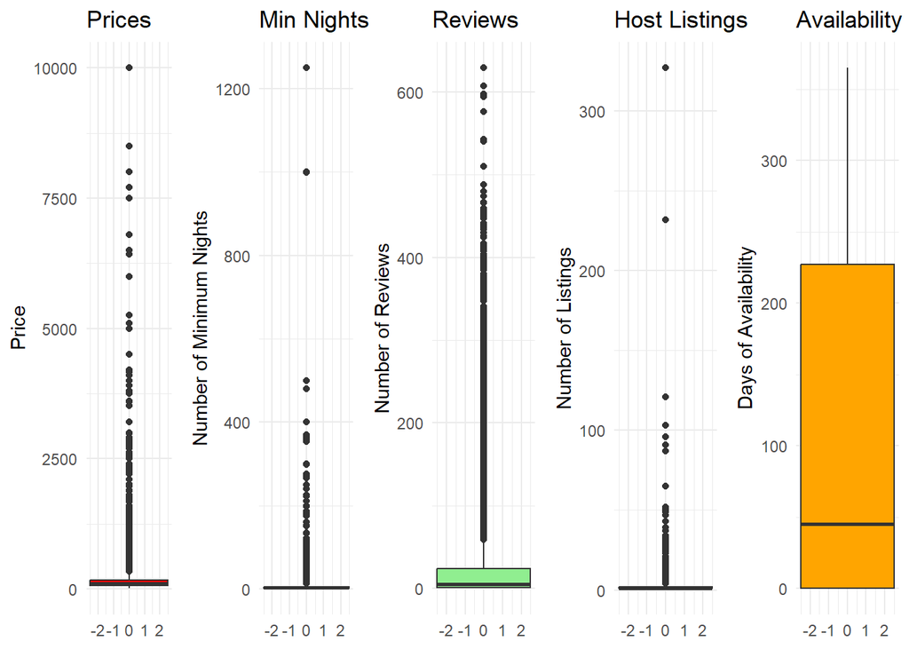

```r
boxplotprice <- ggplot(airbnbclean2, aes(y = price)) +
  geom_boxplot(fill = "red", width = 5) +
  labs(title = "Prices", y = "Price") +
  theme_minimal()

boxplotminnights <- ggplot(airbnbclean2, aes(y = minimum_nights)) +
  geom_boxplot(fill = "lightblue", width = 5) +
  labs(title = "Min Nights", y = "Number of Minimum Nights") +
  theme_minimal()

boxplotreviews <- ggplot(airbnbclean2, aes(y = number_of_reviews)) +
  geom_boxplot(fill = "lightgreen", width = 5) +
  labs(title = "Reviews", y = "Number of Reviews") +
  theme_minimal()

boxplothost <- ggplot(airbnbclean2, aes(y = calculated_host_listings_count)) +
  geom_boxplot(fill = "brown", width = 5) +
  labs(title = "Host Listings", y = "Number of Listings") +
  theme_minimal()

boxplotavail <- ggplot(airbnbclean2, aes(y = availability_365)) +
  geom_boxplot(fill = "orange", width = 5) +
  labs(title = "Availability", y = "Days of Availability") +
  theme_minimal()

grid.arrange(boxplotprice, boxplotminnights, boxplotreviews, boxplothost, boxplotavail, ncol = 5)
```

**Now to remove the outliers and temporary columns from the dataset.**

```r
airbnbnooutliers <- airbnbclean2 |>
  filter(
    !outlierprice &
    !outlierminnights &
    !outlierreviews &
    !outlieravailability)

airbnbnooutliers <- airbnbnooutliers |>
  select(-outlierprice, -outlierminnights, -outlierreviews, -outlieravailability)
```

# **Interpreting the Cleaned Data**

## Price

**Now, we can analyze the price distribution with a histogram and boxplot.**

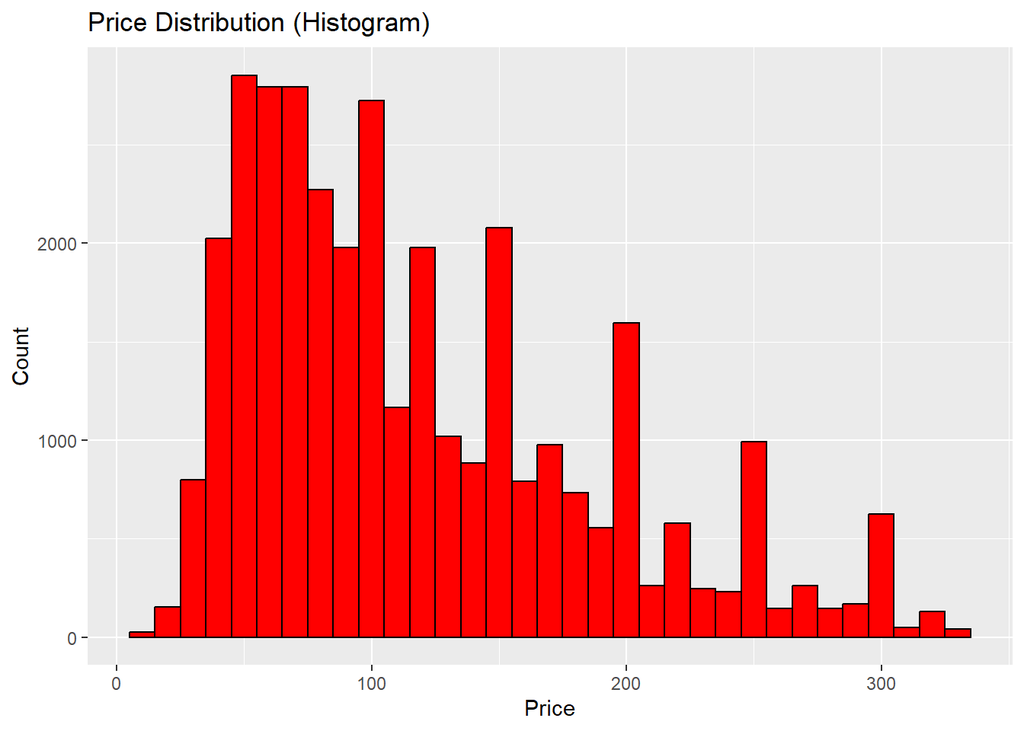

```r
ggplot(airbnbnooutliers, aes(x = price)) +
  geom_histogram(binwidth = 10, fill = "red", color = "black") +
  ggtitle("Price Distribution (Histogram)") +
  xlab("Price") +
  ylab("Count")
```

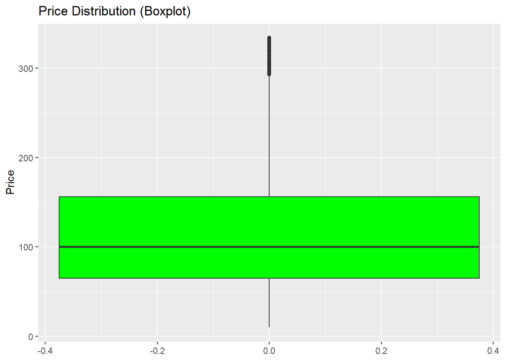

```r
ggplot(airbnbnooutliers, aes(y = price)) +
  geom_boxplot(fill = "green") +
  ggtitle("Price Distribution (Boxplot)") +
  ylab("Price")
```

**From these two plots, we can see that a majority of listings are between $50 and $150.**

## Neighborhood Groups

Let’s look at the average price per neighborhood group and the percentage of listings per neighborhood group.

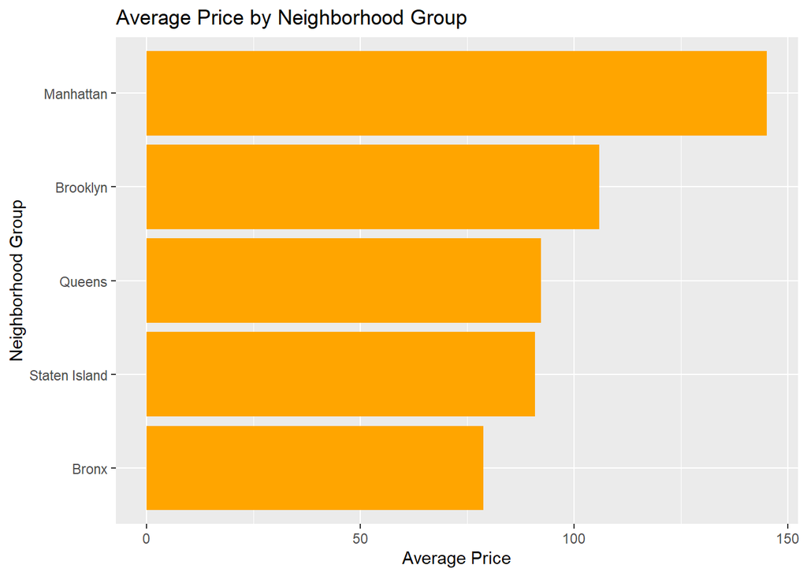

```r
avgneighborhood <- airbnbnooutliers |>
  group_by(neighbourhood_group) |>
  summarise(AvgPrice = mean(price))

ggplot(avgneighborhood, aes(x = reorder(neighbourhood_group, AvgPrice), y = AvgPrice)) +
  geom_bar(stat = "identity", fill = "orange") +
  ggtitle("Average Price by Neighborhood Group") +
  xlab("Neighborhood Group") +
  ylab("Average Price") +
  coord_flip()
```

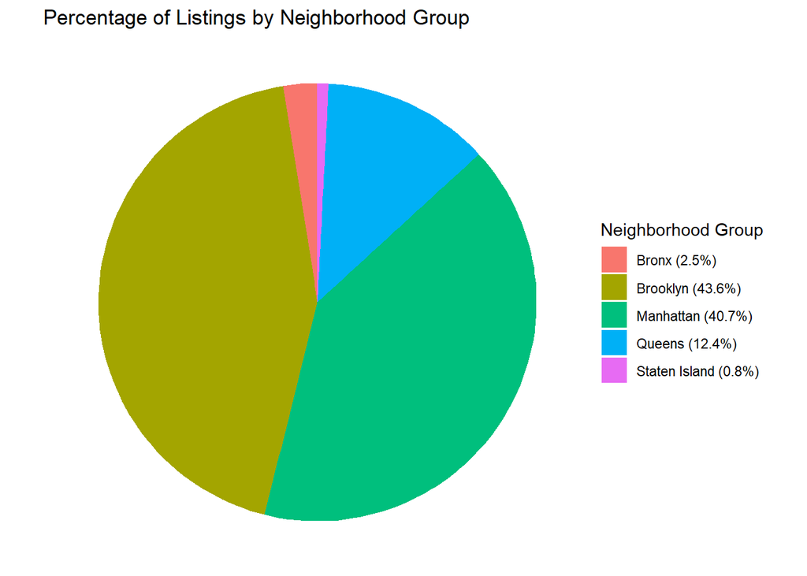

```r
listbyhood <- airbnbnooutliers |>
  count(neighbourhood_group) |>
  arrange(desc(n))


listbyhood <- listbyhood |>
  mutate(Percentage = round(n / sum(n) * 100, 1))

listbyhood$label <- paste0(listbyhood$neighbourhood_group, " (", listbyhood$Percentage, "%)")

ggplot(listbyhood, aes(x = "", y = n, fill = label)) +
  geom_bar(stat = "identity", width = 1) +
  coord_polar(theta = "y") +
  theme_void() +
  labs(
    title = "Percentage of Listings by Neighborhood Group",
    fill = "Neighborhood Group (with %)") +
  scale_fill_discrete(name = "Neighborhood Group")
```

## Neighborhoods

**To go into even finer detail, we can look at some of the top neighborhoods for Airbnb listings.**

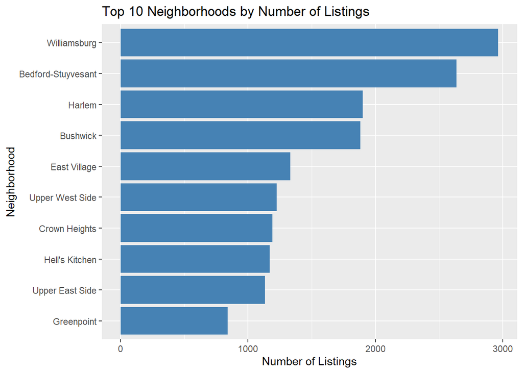

```r
topneighborhoods <- airbnbnooutliers |>
  count(neighbourhood) |>
  arrange(desc(n)) |>
  top_n(10, n)

ggplot(topneighborhoods, aes(x = reorder(neighbourhood, n), y = n)) +
  geom_bar(stat = "identity", fill = "steelblue") +
  coord_flip() +
  labs(
    title = "Top 10 Neighborhoods by Number of Listings",
    x = "Neighborhood",
    y = "Number of Listings")
```

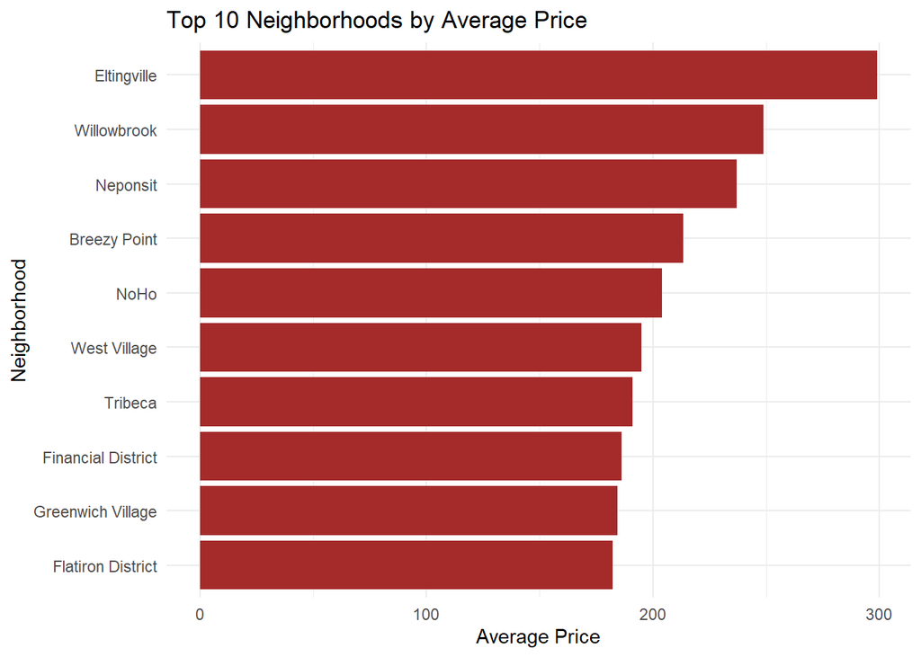

```r
topneighborhoodprices <- airbnbnooutliers |>
  group_by(neighbourhood) |>
  summarise(AvgPrice = mean(price)) |>
  arrange(desc(AvgPrice)) |>
  top_n(10, AvgPrice)

ggplot(topneighborhoodprices, aes(x = reorder(neighbourhood, AvgPrice), y = AvgPrice)) +
  geom_bar(stat = "identity", fill = "brown") +
  coord_flip() +
  labs(
    title = "Top 10 Neighborhoods by Average Price",
    x = "Neighborhood",
    y = "Average Price"
  ) +
  theme_minimal()
```

**As we can see comparing these two plots, there is no overlap whatsoever between the top 10 neighborhoods for listings and the top 10 neighborhoods by average price. The top 10 neighborhoods by listing count show us the areas with the highest demand, while the average price top 10 helps us target more affluent areas.**

## Room Type and Average Price

**Let’s examine the average price of an Airbnb by room type.**

```r
avgpriceroom <- airbnbnooutliers |>
  group_by(room_type) |>
  summarise(AvgPrice = mean(price))

print(avgpriceroom)
```

```
## # A tibble: 3 × 2
##   room_type       AvgPrice
##   <chr>              <dbl>
## 1 Entire home/apt    163.
## 2 Private room        81.1
## 3 Shared room         62.8
```

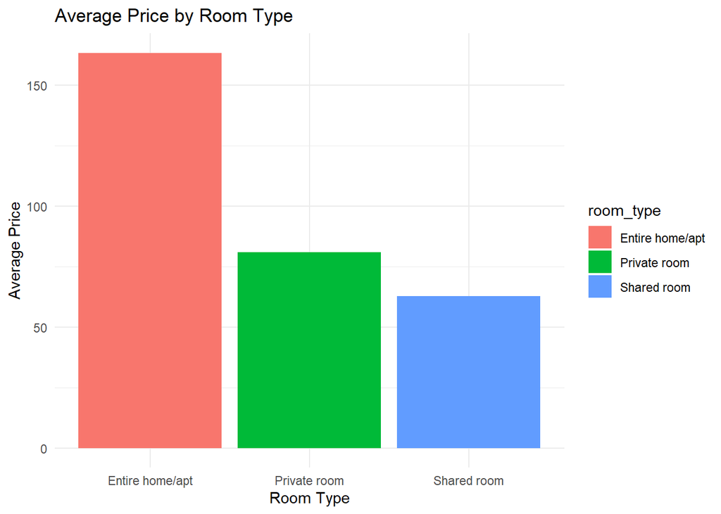

```r
ggplot(avgpriceroom, aes(x = room_type, y = AvgPrice, fill = room_type)) +
  geom_bar(stat = "identity") +
  ggtitle("Average Price by Room Type") +
  xlab("Room Type") +
  ylab("Average Price") +
  theme_minimal()
```

**As we can see, an entire home/apartment is the most expensive option, by a wide margin. Private rooms come in second, while shared rooms are cheapest.**

## Availability

**Let’s examine room availability.**

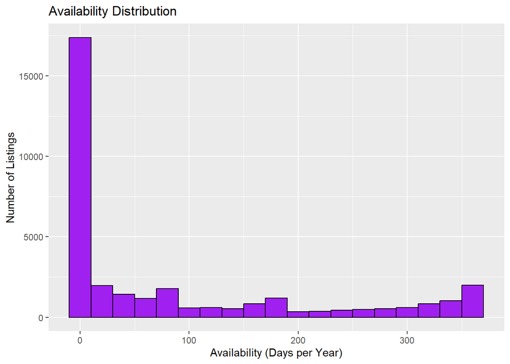

```r
ggplot(airbnbnooutliers, aes(x = availability_365)) +
  geom_histogram(binwidth = 20, fill = "purple", color = "black") +
  ggtitle("Availability Distribution") +
  xlab("Availability (Days per Year)") +
  ylab("Number of Listings")
```

**From our availability distribution, we can see that NYC has a high demand for temporary housing, with over half of the listings already having no availability.**

# Predicting Price with Linear Regression

```r
modeldata <- airbnbnooutliers |>
  select(price, number_of_reviews, availability_365, room_type, neighbourhood_group)

modeldata$room_type <- as.factor(modeldata$room_type)
modeldata$neighbourhood_group <- as.factor(modeldata$neighbourhood_group)

set.seed(123)
trainIndex <- sample(1:nrow(modeldata), 0.8 * nrow(modeldata))
traindata <- modeldata[trainIndex, ]
testdata <- modeldata[-trainIndex, ]

lrmodel <- lm(price ~ number_of_reviews + availability_365 + room_type + neighbourhood_group, data = traindata)

predictions <- predict(lrmodel, newdata = testdata)

comparison <- data.frame(Actual = testdata$price, Predicted = predictions)
head(comparison)
```

```
##   Actual Predicted
## 1     99 134.75401
## 2    150 169.42360
## 3    120 170.06092
## 4     51 100.43652
## 5    190 190.87400
## 6     98  78.02676
```

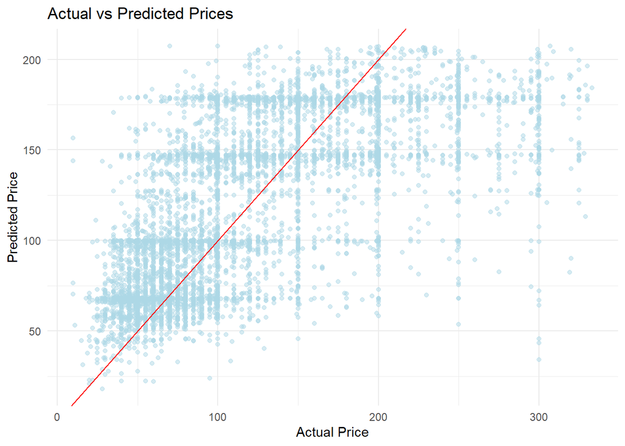

```r
ggplot(comparison, aes(x = Actual, y = Predicted)) +
  geom_point(alpha = 0.5, color = "lightblue") +
  geom_abline(slope = 1, intercept = 0, color = "red") +
  ggtitle("Actual vs Predicted Prices") +
  xlab("Actual Price") +
  ylab("Predicted Price") +
  theme_minimal()
```

```r
summary(lrmodel)
```

```
##
## Call:
## lm(formula = price ~ number_of_reviews + availability_365 + room_type +
##     neighbourhood_group, data = traindata)
##
## Residuals:
##      Min       1Q   Median       3Q      Max
## -189.287  -30.278   -7.739   22.067  255.590
##
## Coefficients:
##                                    Estimate Std. Error  t value Pr(>|t|)
## (Intercept)                       1.251e+02  2.040e+00   61.317  < 2e-16 ***
## number_of_reviews                -2.670e-01  2.226e-02  -11.994  < 2e-16 ***
## availability_365                  7.765e-02  2.608e-03   29.776  < 2e-16 ***
## room_typePrivate room            -7.934e+01  6.222e-01 -127.525  < 2e-16 ***
## room_typeShared room             -1.027e+02  1.927e+00  -53.311  < 2e-16 ***
## neighbourhood_groupBrooklyn       2.217e+01  2.016e+00   11.000  < 2e-16 ***
## neighbourhood_groupManhattan      5.399e+01  2.023e+00   26.688  < 2e-16 ***
## neighbourhood_groupQueens         1.165e+01  2.135e+00    5.456 4.91e-08 ***
## neighbourhood_groupStaten Island -1.348e+00  3.916e+00   -0.344    0.731
## ---
## Signif. codes:  0 '***' 0.001 '**' 0.01 '*' 0.05 '.' 0.1 ' ' 1
##
## Residual standard error: 49.97 on 27246 degrees of freedom
## Multiple R-squared:  0.4564, Adjusted R-squared:  0.4562
## F-statistic:  2859 on 8 and 27246 DF,  p-value: < 2.2e-16
```

## Observations from the Model

**From our linear regression model, we can see that number of reviews, room type, and neighborhood all have a significant influence on price, with room type and neighborhood group having the largest impact on the price of an Airbnb. From our model fit R-squared value (.4562), there can be improvement. We are ideally looking for over .7 for this value, so some factors could be missing. These could include, for example, proximity to public transportation stations, square footage, or proximity to restaurants or tourist destinations.**